# Module 2: Probability Notes

## Probablity Rules

- The probability that nothing occurs is 0
- The probability that something occurs is 1
- The probability that something is 1 - probability of the opposite outcome

$$P(A) = 1 - P(A^c)$$

- The probability of at least one of multiple events that are mutually exclusive occurring is the sum of their probabilities

$$P(A \cup B) = P(A) + P(B)$$

- If A implies B then the probability of A is less than the probability of B
- For any two events the probability that at least one occurs is the sum of their probabilities minus their intersection

$$P(A \cup B) = P(A) + P(B) - P(A \cap B)$$

## Random Variables

### Discrete

Any value among a countable number of possibilities, i.e. coin flips, die rolls

### Continuous

Any value along a range, i.e. temperature, weight

## Probability Mass Function (PMF)

The probability mass function is associated with a discrete random variable. PMF evaluated at a value corresponds to the probability that a random variable takes that values. To be a valid PMF function, *p*, must satisfy:

- Must always be $\geq 0$
- The sum of the possible values must add up to 1

## Probability Density Function (PDF)

The probability density function is associated to a continuous random variable. The areas under PDFs correspond to probabilities for that random variable. To be a valid PDF function, it must satisfy:

- Be $\geq 0$ everywhere
- Total area must be 1

### Example

$f(x) = 2x$ for $0 \leq x \leq 1$

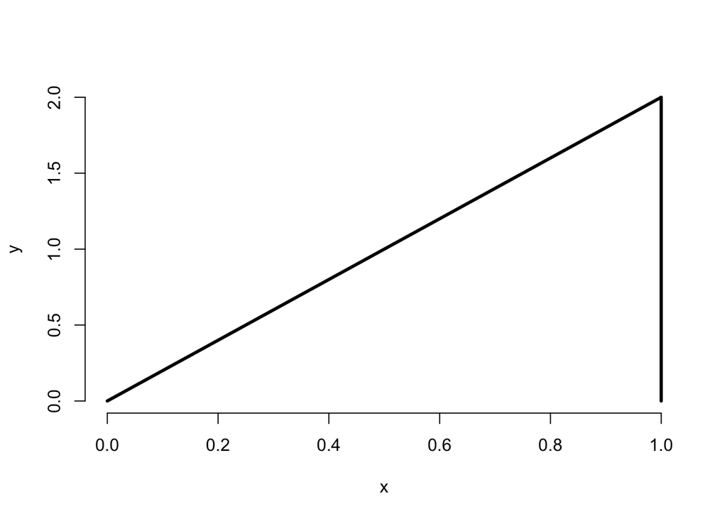

Area must be one for a PDF and the area of a triangle is $(h \times w)/2$.

```r
(2 * 1) / 2
```

```
## [1] 1
```

What’s the probability that 75% or fewer calls get addressed in a day?

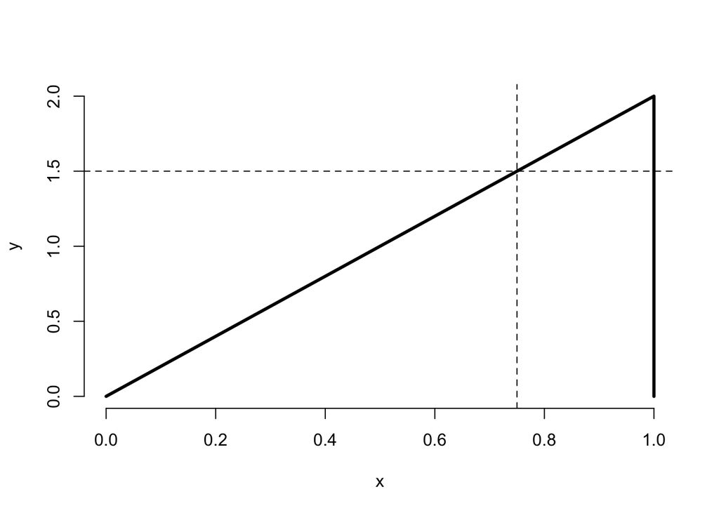

The probability is the area under the portion 0.75, 1.5, which is still a triangle.

```r
(1.5 * 0.75) / 2
```

```
## [1] 0.5625
```

using `pbeta` function

```r
pbeta(0.75, 2, 1)
```

```
## [1] 0.5625
```

## Cumulative Distribution Function (CDF) and Survival Function

The cumulative distribution function of a random variable $X$ (discrete or continuous) returns the probability that the random variable is less than or equal to the value $x$

$$F(x) = P(X \leq x)$$

Note from swirl on CDF:

> When the random variable is continuous, as in the example, the PDF is the derivative of the CDF. So integrating the PDF (the line represented by the diagonal) yields the CDF. When you evaluate the CDF at the limits of integration the result is an area.

Survivor function is the compliment of the CDF

## Exercises

### Question 1

Can you add the probabilities of any two events to get the probability of at least one occurring?

No, this only works for mutually exclusive events.

### Question 2

I define a PMF, $p$ so that for $x=0$ and $x=1$ we have $p(0)=−0.1$ and $p(1)=1.1$. Is this a valid PMF?

No, it is invalid because the probabilities cannot be < 0

### Question 3

What is the probability that 75% or fewer calls get answered in a randomly sampled day from the population distribution from this chapter?

```r
# area under that portion of the triangle
(1.5 * 0.75) / 2
```

```
## [1] 0.5625
```

```r
# using pbeta function
pbeta(0.75, 2, 1)
```

```
## [1] 0.5625
```

### Question 4

The 97.5th percentile of a distribution is?

The point at which 97.5% of the mass of the density lies below it.

### Question 5

Consider influenza epidemics for two parent heterosexual families. Suppose that the probability is 15% that at least one of the parents has contracted the disease. The probability that the father has contracted influenza is 10% while that the mother contracted the disease is 9%. What is the probability that both contracted influenza expressed as a whole number percentage?

$$P(M) = 0.10$$

$$P(F) = 0.09$$

$$P(M \cup F) = 0.15$$
$$P(M) + P(F) - P(M \cap F)= 0.15$$
$$0.10 + 0.09 - P(M \cap F)= 0.15$$
$$P(M \cap F)= 0.04$$
$$\color{blue}{4\%}$$

### Question 6

A random variable, $X$, is uniform, a box from 0 to 1 of height 1. (So that it’s density is $f(x)=1$ for $0≤x≤1$.) What is it’s median expressed to two decimal places?

$f(x) = 1$

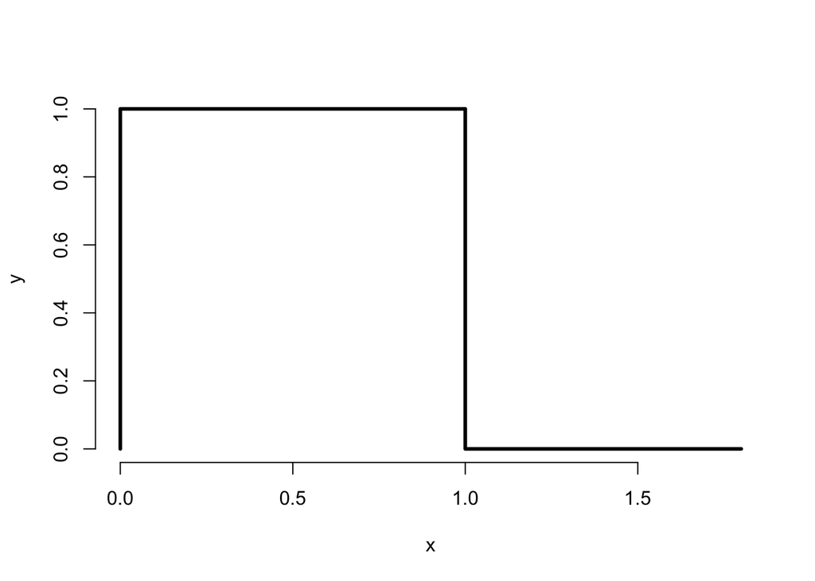

$f(x) = 1$

$F(x) = P(X≤x) = x \times 1.0 = x$

Median (0.5) would be for $x = \color{blue}{0.50}$

### Question 7

If a continuous density that never touches the horizontal axis is symmetric about zero, can we say that its associated median is zero?

Yes, because half of its mass is above zero and the other below.